# BIOF 339 Final Presentation: Running an Easier 5k

December 11, 2019

## Putting R to Practical Use

Goal of helping a high school Music Educator use R code to better serve the needs of managing a 5k fundraiser to support Arts Education.

Requiring quick analysis of current data and a customizable output in the form of an email for registered fundraisers to continue their work and boost the overall donation totals.

[figure not shown]

## Current Data Collection Formats

- Google Forms output (Student Registration)
- Downloaded online donor data to Excel file
- Used Google Add-ons (Autocrat and Form Mule) to generate reports

[figure not shown]

## Spreadsheets Requires Time and Energy

The 2019 annual campaign was effective this year because of the diligence of the administrator taking time to learn manipulation of Google sheets by joining tables and manually reconstructing datasets at periodic timepoints that generated e-mail merges of current totals for the student fundraisers.

Since this is an annual event, my hope was to create a foundation in R code for future events to run just as well, but without needing as much manual attention.

- Functions written in R to pull current data
- Using library(gmailr) to report back to fundraisers

## Dataset Built From Google Form Results

[figure not shown]

## Tedious Manual Labor

## Merge Data Across Multiple Spreadsheets

## Multiple Reconstruction of Current Data

## Presentation Goals

- Data ingestion
- Data Munging and Analysis
- Graphical output
- Eventual alignment with gmailr to report

## Data

## Dataset of Registered Students

```r
str(Nov10data)
```

#### Output omitted for privacy

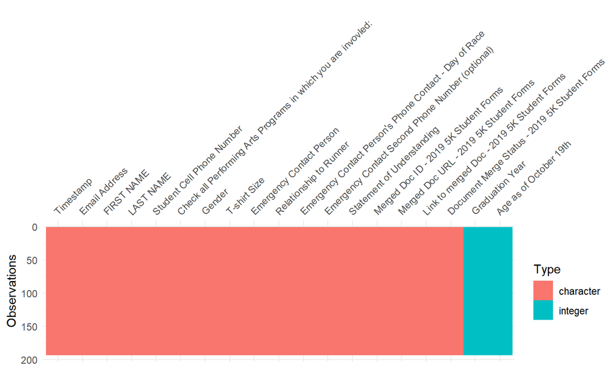

```r
vis_dat(Nov10data)
```

## Dataset of Online Donations

```r
str(dondat)
```

#### Output omitted for privacy

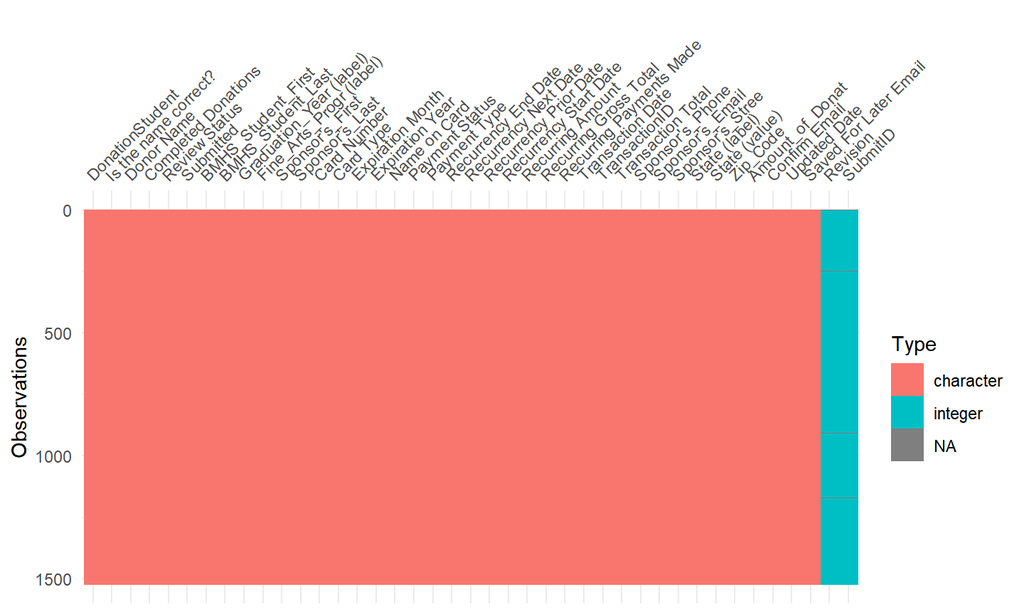

```r
vis_dat(dondat)
```

## Munging the Data

- Review Variables to determine which are relevant for future questions regarding student donation totals
- Convert status of those variables to numeric
- Clean data
- Write functions to simplify parsing information from repetative tasks

## Variables of Interest

Student Registration Data

- $ Email Address
- $ First Name
- $ Last Name

Donation Data

- $ BMHS_Student_First
- $ BMHS_Student_Last
- $ Payment Status
- $ Transaction Total
- $ Amount_of_Donation

## Create Datasets of Selected Variables

```r
students <- select(Nov10data, 'Email Address', ends_with('Name'))
donor <- select(dondat, 'BMHS_Student_First', 'BMHS_Student_Last', 'Payment Status','Transaction Total', 'Amount_of_Donat')
str(students)
```

```r
str(unique(students$`Email Address`))
```

```r
str(donor)
```

```
## 'data.frame':    1523 obs. of  5 variables:
##  $ BMHS_Student_First: chr  "Could be wrong" "Aaron" "Abigail" "Abby" ...
##  $ BMHS_Student_Last : chr  "Could be wrong" "McDonald" "Taylor" "Taulor" ...
##  $ Payment Status    : chr  "" "Completed" "Completed" "Abandoned" ...
##  $ Transaction Total : chr  "AMOUNT" "$75.00" "25" "$500.00" ...
##  $ Amount_of_Donat   : chr  "" "$75.00" "25" "$500.00" ...
```

## Convert Values

```r
donor$`Payment Status` <-  as.factor(donor$`Payment Status`)
donor$`Transaction Total` <- as.numeric(donor$`Transaction Total`)
donor$Amount_of_Donat <-  as.numeric(donor$Amount_of_Donat)
str(donor)
```

```
## 'data.frame':    1523 obs. of  5 variables:
##  $ BMHS_Student_First: chr  "Could be wrong" "Aaron" "Abigail" "Abby" ...
##  $ BMHS_Student_Last : chr  "Could be wrong" "McDonald" "Taylor" "Taulor" ...
##  $ Payment Status    : Factor w/ 6 levels "","abandoned",..: 1 5 5 3 5 5 5 5 5 3 ...
##  $ Transaction Total : num  NA NA 25 NA NA NA 50 500 20 50 ...
##  $ Amount_of_Donat   : num  NA NA 25 NA NA NA 50 500 20 50 ...
```

## Where are the NAs

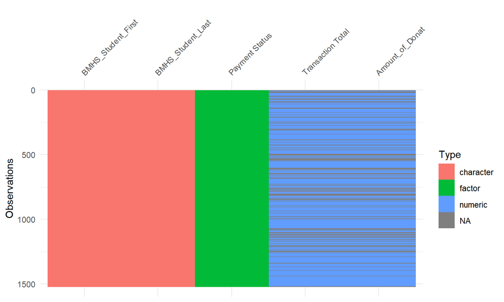